# Data Mining Lab 4

Jonathan Kuek

21 November 2015

```r
library(ISLR)
library(gam)
library(randomForest)
str(College)
```

```
## 'data.frame':    777 obs. of  18 variables:
##  $ Private    : Factor w/ 2 levels "No","Yes": 2 2 2 2 2 2 2 2 2 2 ...
##  $ Apps       : num  1660 2186 1428 417 193 ...
##  $ Accept     : num  1232 1924 1097 349 146 ...
##  $ Enroll     : num  721 512 336 137 55 158 103 489 227 172 ...
##  $ Top10perc  : num  23 16 22 60 16 38 17 37 30 21 ...
##  $ Top25perc  : num  52 29 50 89 44 62 45 68 63 44 ...
##  $ F.Undergrad: num  2885 2683 1036 510 249 ...
##  $ P.Undergrad: num  537 1227 99 63 869 ...
##  $ Outstate   : num  7440 12280 11250 12960 7560 ...
##  $ Room.Board : num  3300 6450 3750 5450 4120 ...
##  $ Books      : num  450 750 400 450 800 500 500 450 300 660 ...
##  $ Personal   : num  2200 1500 1165 875 1500 ...
##  $ PhD        : num  70 29 53 92 76 67 90 89 79 40 ...
##  $ Terminal   : num  78 30 66 97 72 73 93 100 84 41 ...
##  $ S.F.Ratio  : num  18.1 12.2 12.9 7.7 11.9 9.4 11.5 13.7 11.3 11.5 ...
##  $ perc.alumni: num  12 16 30 37 2 11 26 37 23 15 ...
##  $ Expend     : num  7041 10527 8735 19016 10922 ...
##  $ Grad.Rate  : num  60 56 54 59 15 55 63 73 80 52 ...
```

```r
set.seed(222) #making sure that the results are the same when I knit the markdown file by choosing the same sample
sub <- sample(nrow(College), floor(nrow(College) * 0.8))
training <- College[sub, ]
testing <- College[-sub, ]
```

(1a)

```r
# lm() and step() functions
ols <- lm(Outstate ~ as.factor(Private) + Accept + Top10perc + Top25perc + F.Undergrad + Expend + Room.Board + Personal + perc.alumni + Expend:F.Undergrad, data = training)
# For data mining we are not concerned about any of the coefficients nor the null hypothesis because we dont even distinguish between
# sample and population.

step_ols <- step(ols)
```

```
## Start:  AIC=9507
## Outstate ~ as.factor(Private) + Accept + Top10perc + Top25perc +
##     F.Undergrad + Expend + Room.Board + Personal + perc.alumni +
##     Expend:F.Undergrad
##
##                      Df Sum of Sq        RSS    AIC
## - Top25perc           1    406820 2669728477 9505.1
## <none>                            2669321657 9507.0
## - Top10perc           1  16157614 2685479271 9508.8
## - Personal            1  18476977 2687798634 9509.3
## - F.Undergrad:Expend  1  75416902 2744738560 9522.3
## - Accept              1 107899787 2777221445 9529.6
## - perc.alumni         1 167709617 2837031274 9542.8
## - as.factor(Private)  1 357420005 3026741663 9583.0
## - Room.Board          1 533895215 3203216873 9618.2
##
## Step:  AIC=9505.1
## Outstate ~ as.factor(Private) + Accept + Top10perc + F.Undergrad +
##     Expend + Room.Board + Personal + perc.alumni + F.Undergrad:Expend
##
##                      Df Sum of Sq        RSS    AIC
## <none>                            2669728477 9505.1
## - Personal            1  18510403 2688238880 9507.4
## - Top10perc           1  63198197 2732926674 9517.6
## - F.Undergrad:Expend  1  78106013 2747834490 9521.0
## - Accept              1 110254292 2779982770 9528.2
## - perc.alumni         1 171771596 2841500073 9541.8
## - as.factor(Private)  1 357088057 3026816534 9581.1
## - Room.Board          1 537276427 3207004904 9617.0
```

```r
summary(step_ols)
```

```
##
## Call:
## lm(formula = Outstate ~ as.factor(Private) + Accept + Top10perc +
##     F.Undergrad + Expend + Room.Board + Personal + perc.alumni +
##     F.Undergrad:Expend, data = training)
##
## Residuals:
##     Min      1Q  Median      3Q     Max
## -8198.3 -1338.9   -76.6  1382.0  8146.9
##
## Coefficients:
##                         Estimate Std. Error t value Pr(>|t|)
## (Intercept)           -6.068e+02  5.111e+02  -1.187 0.235579
## as.factor(Private)Yes  2.422e+03  2.679e+02   9.040  < 2e-16 ***
## Accept                 3.641e-01  7.248e-02   5.023 6.68e-07 ***
## Top10perc              2.608e+01  6.857e+00   3.803 0.000157 ***
## F.Undergrad            4.482e-02  6.190e-02   0.724 0.469299
## Expend                 3.061e-01  3.284e-02   9.323  < 2e-16 ***
## Room.Board             1.084e+00  9.773e-02  11.089  < 2e-16 ***
## Personal              -2.956e-01  1.436e-01  -2.058 0.039991 *
## perc.alumni            5.480e+01  8.739e+00   6.270 6.83e-10 ***
## F.Undergrad:Expend    -2.235e-05  5.286e-06  -4.228 2.72e-05 ***
## ---
## Signif. codes:  0 '***' 0.001 '**' 0.01 '*' 0.05 '.' 0.1 ' ' 1
##
## Residual standard error: 2090 on 611 degrees of freedom
## Multiple R-squared:  0.7377, Adjusted R-squared:  0.7338
## F-statistic: 190.9 on 9 and 611 DF,  p-value: < 2.2e-16
```

I have included one interaction term (Expend * F.Undergrad) into the equation.

(1b) & (1c)

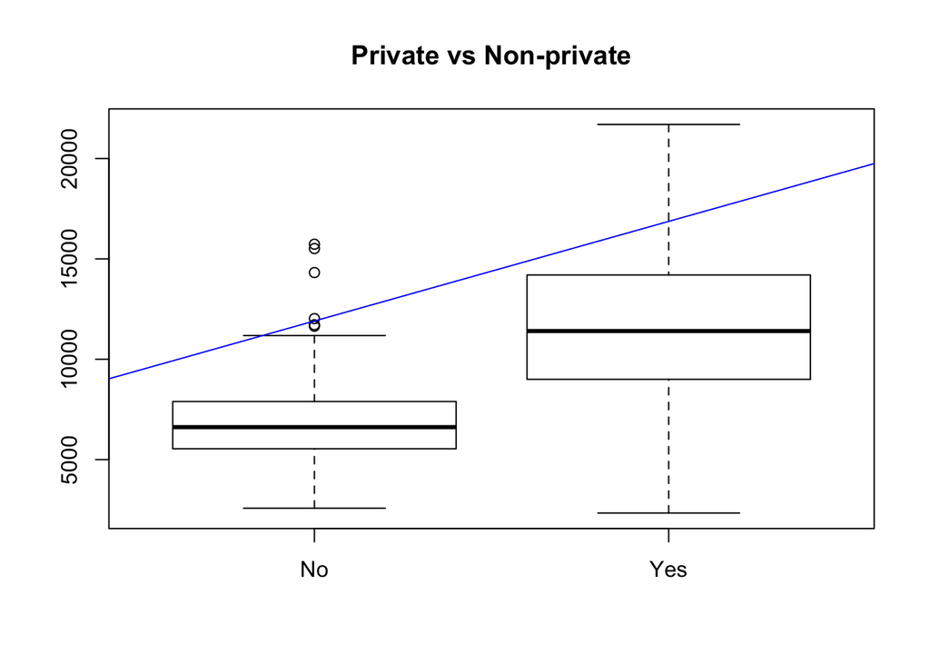

```r
#Obtaining the degrees of freedom for the splines

plot(training$Private, training$Outstate)
title("Private vs Non-private")
ols_fit_Private <- lm(Outstate ~ Private, data = training)
abline(ols_fit_Private, col = "blue")
```

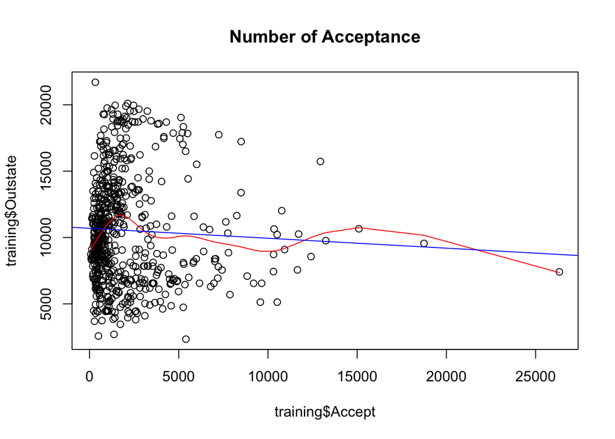

```r
plot(training$Accept, training$Outstate)
title("Number of Acceptance")
fit_Accept <- smooth.spline(training$Accept, training$Outstate, cv = TRUE)
lines(fit_Accept, col = "red")
ols_fit_Accept <- lm(Outstate ~ Accept, data = training)
abline(ols_fit_Accept, col = "blue")
```

```r
fit_Accept$df
```

```
## [1] 8.023008
```

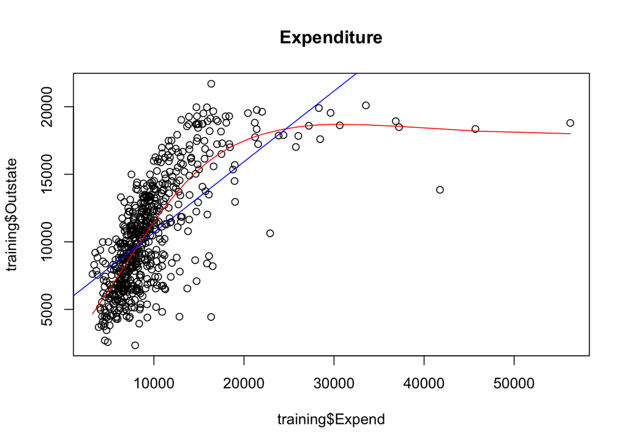

```r
plot(training$Expend, training$Outstate)
title("Expenditure")
fit_Expend <- smooth.spline(training$Expend, training$Outstate, cv = TRUE)
lines(fit_Expend, col = "red")
ols_fit_Expend <- lm(Outstate ~ Expend, data = training)
abline(ols_fit_Expend, col = "blue")
```

```r
fit_Expend$df
```

```
## [1] 4.847102
```

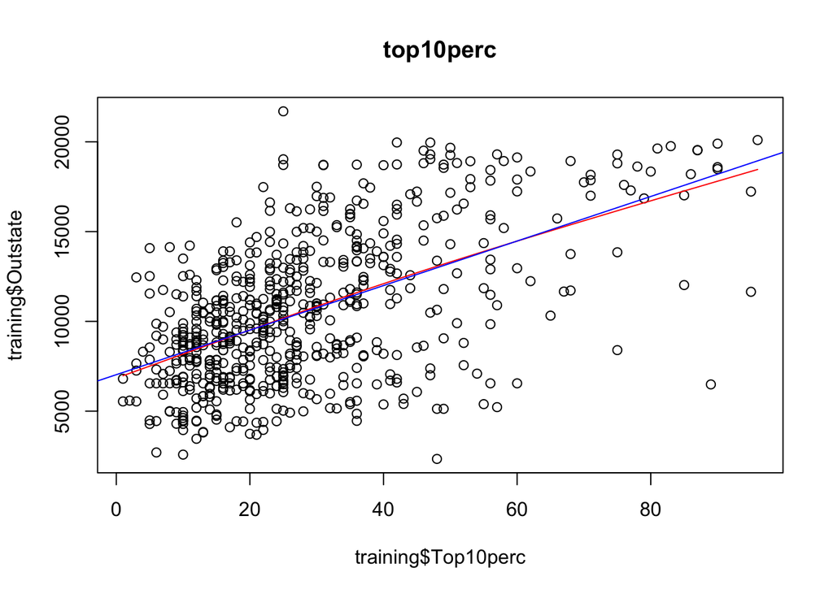

```r
plot(training$Top10perc, training$Outstate)
title("top10perc")
fit_top10perc <- smooth.spline(training$Top10perc, training$Outstate, cv = TRUE)
lines(fit_top10perc, col = "red")
ols_fit_top10perc <- lm(Outstate ~ Top10perc, data = training)
abline(ols_fit_top10perc, col = "blue")
```

```r
fit_top10perc$df
```

```
## [1] 2.552124
```

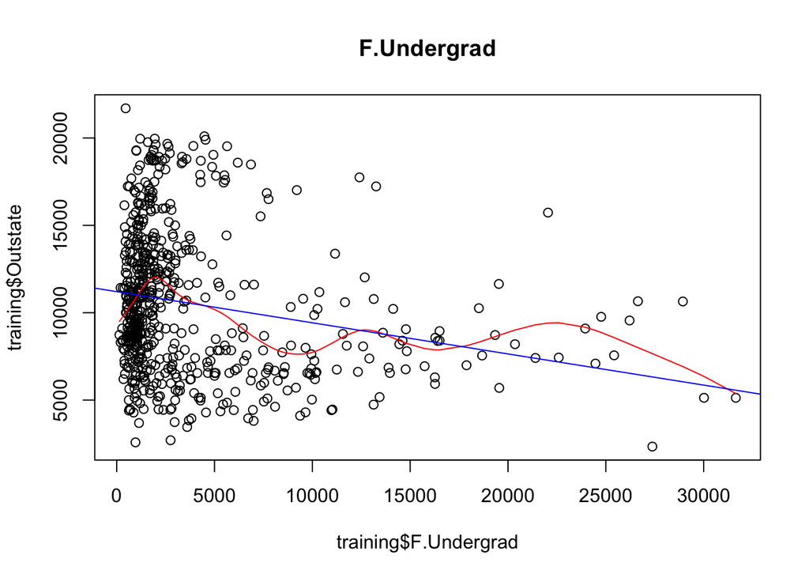

```r
plot(training$F.Undergrad, training$Outstate)
title("F.Undergrad")
fit_F_Undergrad <- smooth.spline(training$F.Undergrad, training$Outstate, cv = TRUE)
lines(fit_F_Undergrad, col = "red")
ols_fit_F_Undergrad <- lm(Outstate ~ F.Undergrad, data = training)
abline(ols_fit_F_Undergrad, col = "blue")
```

```r
fit_F_Undergrad$df
```

```
## [1] 11.08174
```

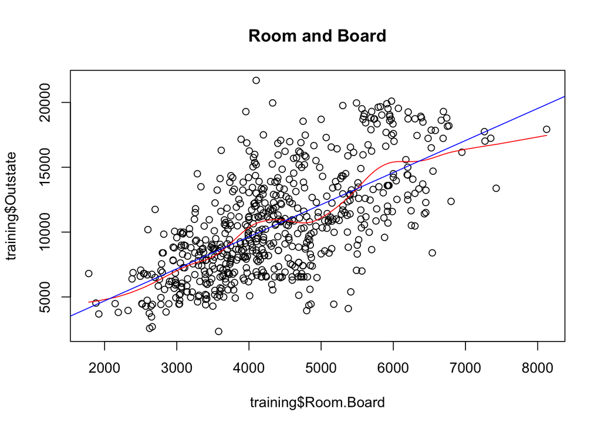

```r
plot(training$Room.Board, training$Outstate)
title("Room and Board")
fit_Room_Board <- smooth.spline(training$Room.Board, training$Outstate, cv = TRUE)
lines(fit_Room_Board, col = "red")
ols_fit_Room_Board <- lm(Outstate ~ Room.Board, data = training)
abline(ols_fit_Room_Board, col = "blue")
```

```r
fit_Room_Board$df
```

```
## [1] 10.59403
```

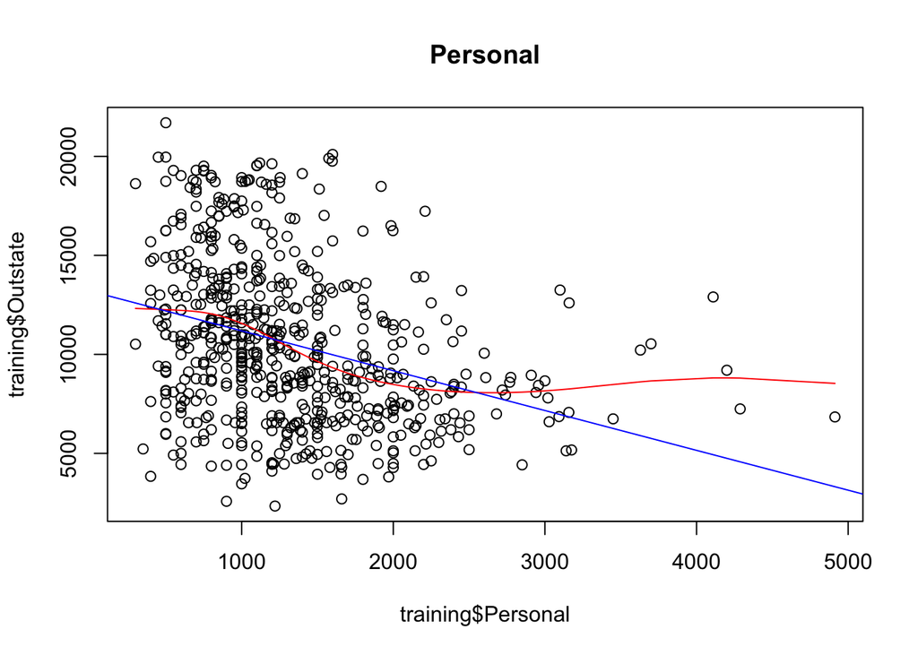

```r
plot(training$Personal, training$Outstate)
title("Personal")
fit_Personal <- smooth.spline(training$Personal, training$Outstate, cv = TRUE)
lines(fit_Personal, col = "red")
ols_fit_Personal <- lm(Outstate ~ Personal, data = training)
abline(ols_fit_Personal, col = "blue")
```

```r
fit_Personal$df
```

```
## [1] 5.48957
```

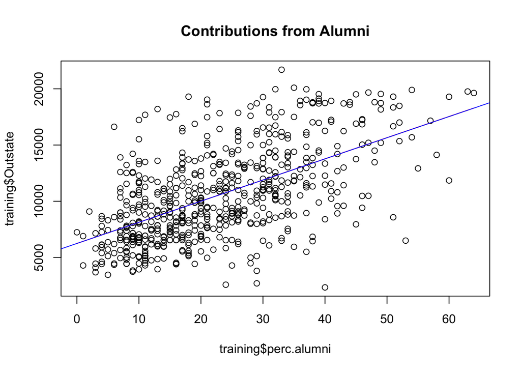

```r
plot(training$perc.alumni, training$Outstate)
title("Contributions from Alumni")
fit_perc_alumni <- smooth.spline(training$perc.alumni, training$Outstate, cv = TRUE)
lines(fit_perc_alumni, col = "red")
ols_fit_perc_alumni <- lm(Outstate ~ perc.alumni, data = training)
abline(ols_fit_perc_alumni, col = "blue")
```

```r
fit_perc_alumni$df
```

```
## [1] 2.000205
```

The predictors that are non-linear are Accept, Expend, F.Undergrad, Room.Board and Personal according to the plots above.

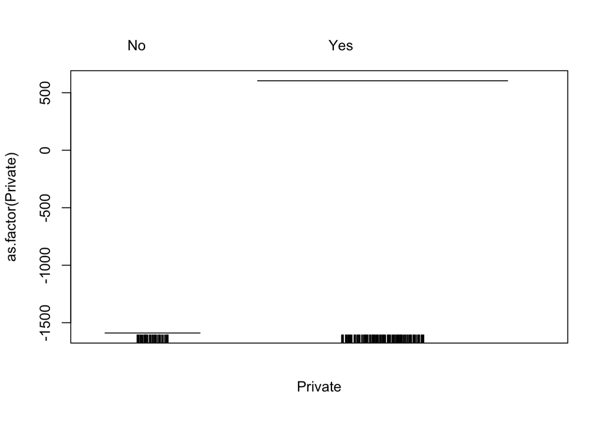

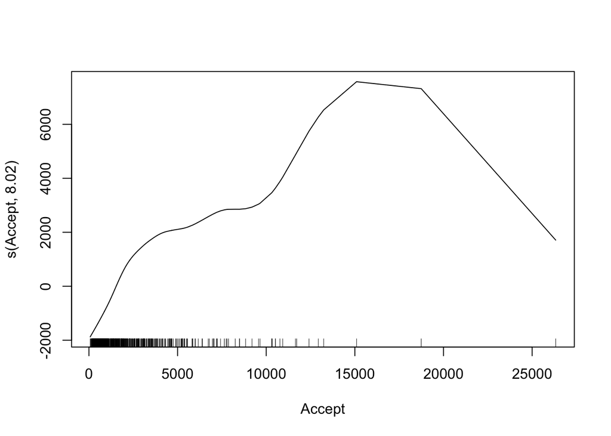

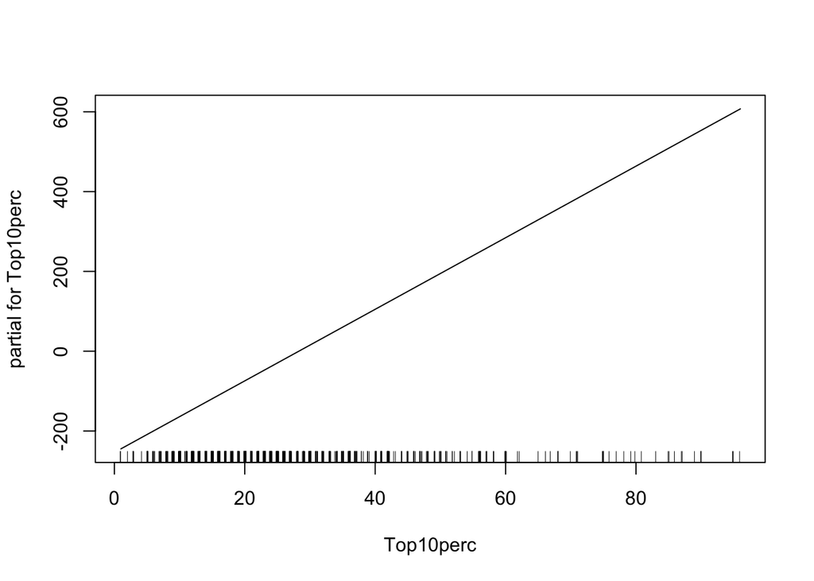

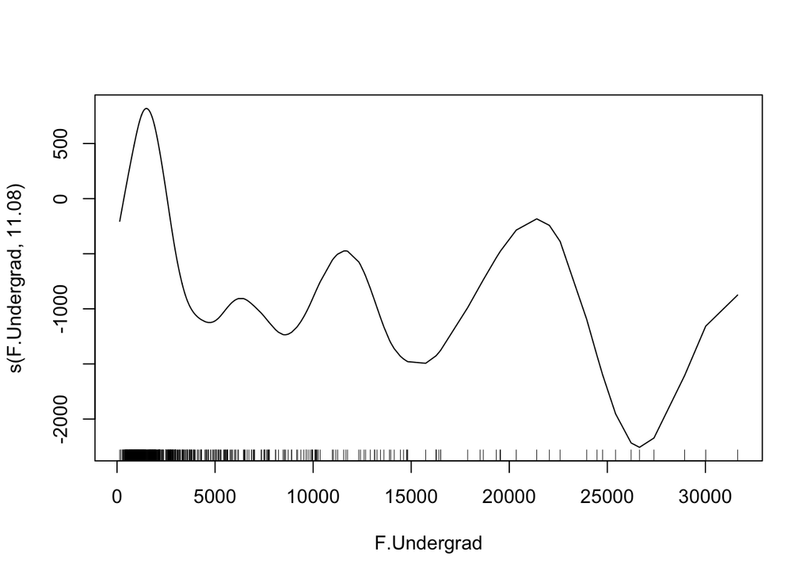

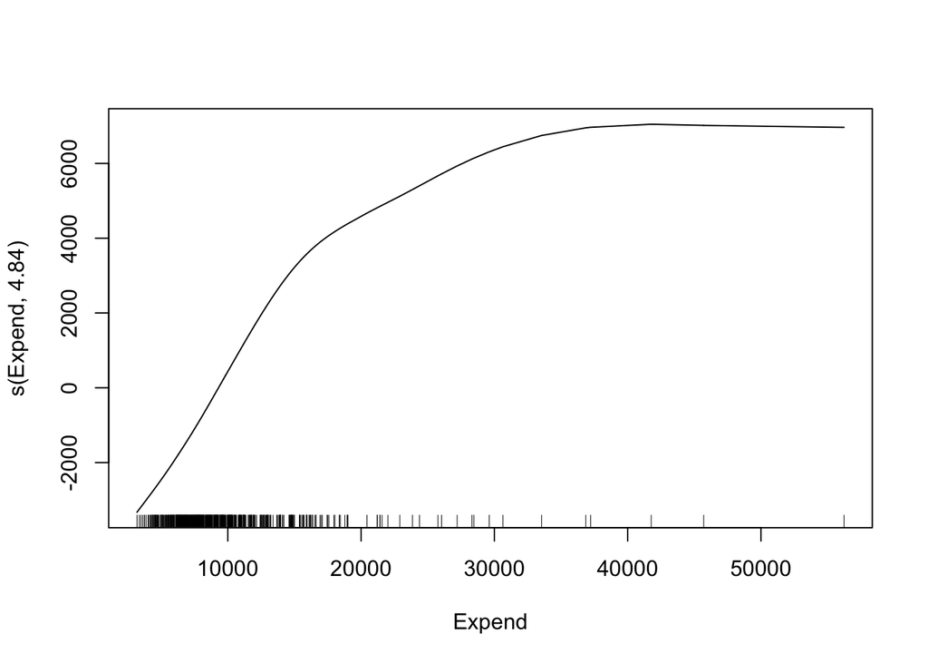

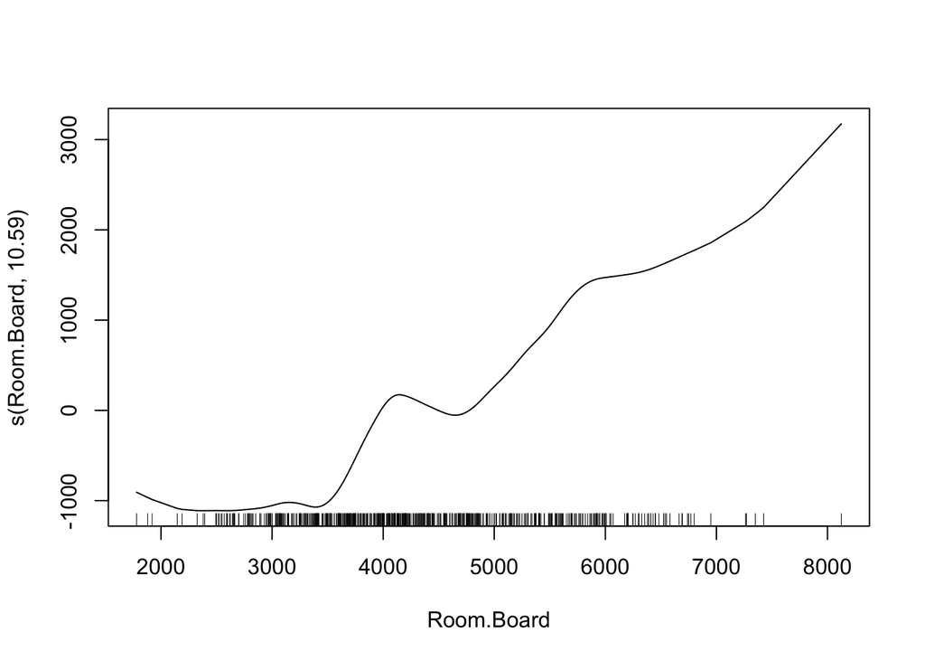

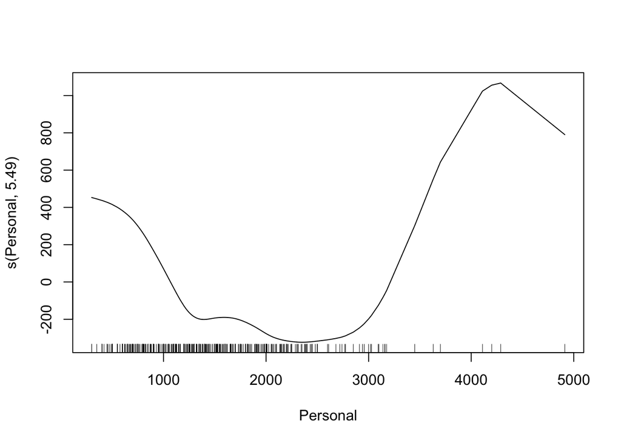

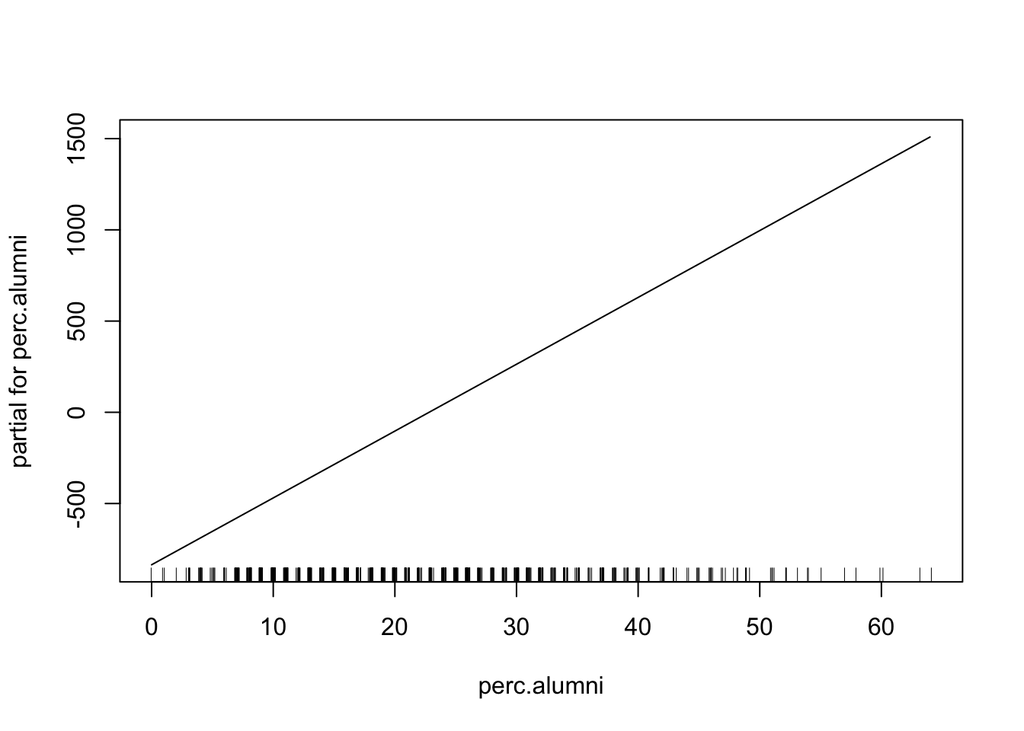

```r
gam_outstate_splined <- gam(Outstate ~ as.factor(Private) + s(Accept, 8.02) + Top10perc + s(F.Undergrad, 11.08) + s(Expend, 4.84) + s(Room.Board, 10.59) + s(Personal, 5.49) + perc.alumni + Expend:F.Undergrad, data = training)

try(plot.gam(gam_outstate_splined))
```

Calling plot on gam gives us the different plots of the different predictors versus the outcome (Outstate). The lines at the bottom represent the distribution of the points. The plots here resemble the individual plots I plotted above using smooth.scatter.

(1d)

```r
#testing for squared errors
gam_outstate_training <- predict(gam_outstate_splined, newdata = training)
gam_outstate_testing <- predict(gam_outstate_splined, newdata = testing)

mean((training$Outstate - gam_outstate_training) ^ 2)
```

```
## [1] 2950644
```

```r
mean((testing$Outstate - gam_outstate_testing) ^ 2)
```

```
## [1] 2637353
```

The training data mean squared error is 2950644 while the testing data mean squared error is 2637353 so the testing data mean squared error is smaller which is surprising. I would have expected that the mean squared error for the testing data to be bigger than the training data because it would have overfitted in the training data and thus give a higher mean squared error in the testing data.

This might have been a one off case where my testing data set exhibits a better fit than the training data and the results might be different if I set a different seed above.

```r
load("dataset2.RData")
str(dataset)
```

```
## 'data.frame':    10000 obs. of  6 variables:
##  $ Amount.Requested    : num  20000 3000 8000 7000 20000 1000 35000 10000 1000 3000 ...
##  $ Debt.To.Income.Ratio: num  11.1 1.38 15.84 14.88 21.37 ...
##  $ Zip.Code            : chr  "639" "080" "606" "336" ...
##  $ State               : chr  "MO" "NJ" "IL" "FL" ...
##  $ Employment.Length   : num  0 5 0 6 0 0 3 0 0 0 ...
##  $ y                   : int  0 0 0 1 0 0 0 0 0 0 ...
```

(2a)

```r
sub_dataset <- sample(nrow(dataset), floor(nrow(dataset) * 0.8))
training_dataset <- dataset[sub_dataset, ]
testing_dataset <- dataset[-sub_dataset, ]

training_dataset$y <- as.factor(training_dataset$y)
testing_dataset$y <- as.factor(testing_dataset$y)

# Logit
logit <- glm(y ~ Amount.Requested + Debt.To.Income.Ratio + Employment.Length, family = "binomial", data = training_dataset)
summary(logit)
```

```
##
## Call:
## glm(formula = y ~ Amount.Requested + Debt.To.Income.Ratio + Employment.Length,
##     family = "binomial", data = training_dataset)
##
## Deviance Residuals:
##     Min       1Q   Median       3Q      Max
## -1.6005  -0.2660  -0.2467  -0.2202   2.8717
##
## Coefficients:
##                        Estimate Std. Error z value Pr(>|z|)
## (Intercept)          -3.397e+00  1.050e-01 -32.346  < 2e-16 ***
## Amount.Requested      1.407e-05  4.577e-06   3.075 0.002108 **
## Debt.To.Income.Ratio -1.221e-02  3.144e-03  -3.884 0.000103 ***
## Employment.Length     3.860e-01  1.149e-02  33.599  < 2e-16 ***
## ---
## Signif. codes:  0 '***' 0.001 '**' 0.01 '*' 0.05 '.' 0.1 ' ' 1
##
## (Dispersion parameter for binomial family taken to be 1)
##
##     Null deviance: 4619.7  on 7999  degrees of freedom
## Residual deviance: 3209.4  on 7996  degrees of freedom
## AIC: 3217.4
##
## Number of Fisher Scoring iterations: 12
```

```r
predictions <- predict(logit, newdata = testing_dataset)
z_model <- as.integer(predictions > 0.5)
table(testing_dataset$y, z_model)
```

```
##    z_model
##        0    1
##   0 1798   30
##   1  147   25
```

(2b)

```r
# bagging
bagged <- randomForest(y ~ Amount.Requested + Debt.To.Income.Ratio + Employment.Length, data = training_dataset,
                       mtry = 3, importance = TRUE)
bagged
```

```
##
## Call:
##  randomForest(formula = y ~ Amount.Requested + Debt.To.Income.Ratio +      Employment.Length, data = training_dataset, mtry = 3, importance = TRUE)
##                Type of random forest: classification
##                      Number of trees: 500
## No. of variables tried at each split: 3
##
##         OOB estimate of  error rate: 6.91%
## Confusion matrix:
##      0   1 class.error
## 0 7075 252  0.03439334
## 1  301 372  0.44725111
```

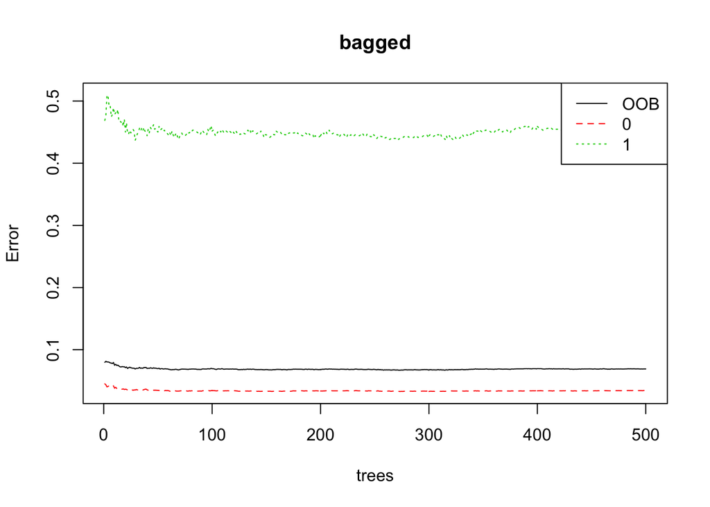

```r
pb <- plot(bagged)
legend("topright", legend = colnames(pb), col = 1:3, lty = 1:3)
```

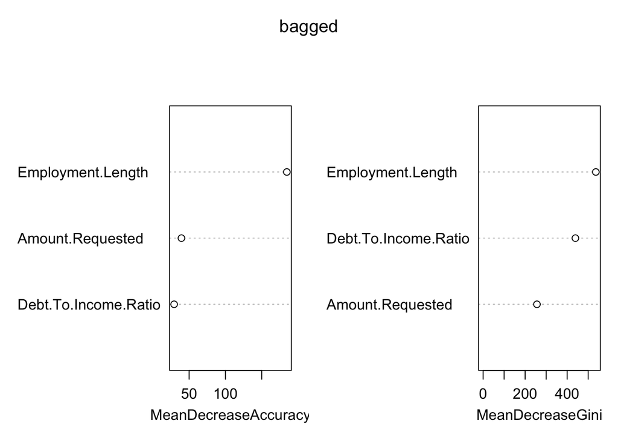

```r
varImpPlot(bagged)
```

```r
predictions <- predict(bagged, newdata = testing_dataset, type = "class")
table(testing_dataset$y, predictions)
```

```
##    predictions
##        0    1
##   0 1762   66
##   1   75   97
```

```r
library(bartMachine)
# BART
set_bart_machine_num_cores(parallel::detectCores())
```

```
## bartMachine now using 4 cores.
```

```r
bart <- bartMachine(X = training_dataset[,c(1,2,5)], y = training_dataset$y)
```

```
## bartMachine initializing with 50 trees...
## Now building bartMachine for classification ...
## evaluating in sample data...done
```

```r
bart
```

```
## bartMachine v1.2.0 for classification
##
## training data n = 8000 and p = 3
## built in 33.7 secs on 4 cores, 50 trees, 250 burn-in and 1000 post. samples
##
## confusion matrix:
##
##            predicted 0 predicted 1 model errors
## actual 0      7130.000     197.000        0.027
## actual 1       233.000     440.000        0.346
## use errors       0.032       0.309        0.054
```

```r
predictions <- predict(bart, new_data = testing_dataset[,c(1,2,5)], type = "class")
table(testing_dataset$y, predictions)
```

```
##    predictions
##        0    1
##   0 1768   60
##   1   53  119
```

(2c)